# Excludes use variables - Self-organizing map analysis of spring runoff from Mt Mansfield

Dustin Kincaid

1/7/2021

#### Objective

Cluster daily environmental drivers to assess how they converge to drive spring runoff patterns from east-side Mt Mansfield watersheds  
This version excludes the variables quanitying the water diverted by the ski resort (“use” variables)

#### Select variables to keep

If two variables are strongly correlated (negatively or positively) they can effectively “double-weight” a particular factor important in driving clustering; thus, keep just one of the variables to serve as a proxy for that factor

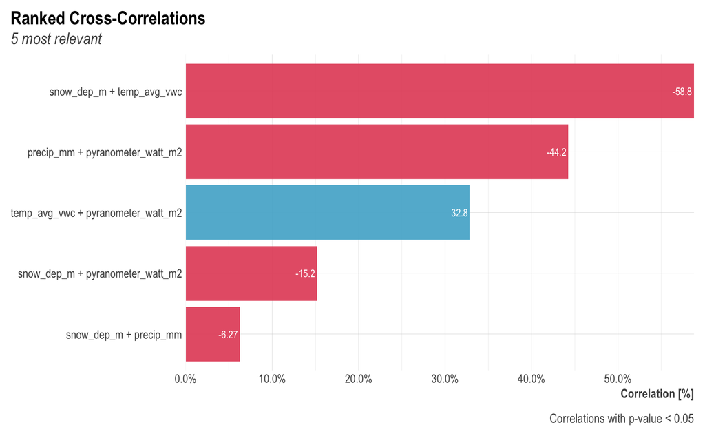

Looks like we won’t need to remove any variables based on correlations

#### Self-organizing map (SOM)

##### Prepare data & set up grid/lattice dimensions

We’re only using complete observations/rows (no NAs in any columns)  
According to the heuristic rule from Vesanto 2000, number of grid elements/grid size/nodes = 5 * sqrt(n)  
To determine the the shape of the grid (ratio of columns to rows), we use the ratio of the first two eigen values of the input data set as recommended by Park et al. 2006

```
## [1] No. of complete observations: 1229 out of 1254 observations
```

```
## [1] No. of Vesanto nodes: 175
```

```
## [1] Ratio of columns to rows: 1.3
```

##### Run SOM for a suite of grid/lattice configurations, # of nodes, and # of clusters

Code courtesy of Kristen Underwood (hidden)

```
## [1] Topology: hexagonal
```

```
## [1] Data normalization method used: L2norm
```

```
## [1] Weighting method used: noPCA
```

```
## [1] No. of iterations: 1000
```

```
## [1] alphaCrs used: 0.05
```

```
## [1] alphaFin used: 1000
```

##### Choose the best SOM run based on non-parametric F-stat and quantization error

We want to maximize npF (ratio of b/w cluster variance) and minimize QE (mean distance b/w each data vector & best-matching unit)  
Here are the top 50% of runs based on npF

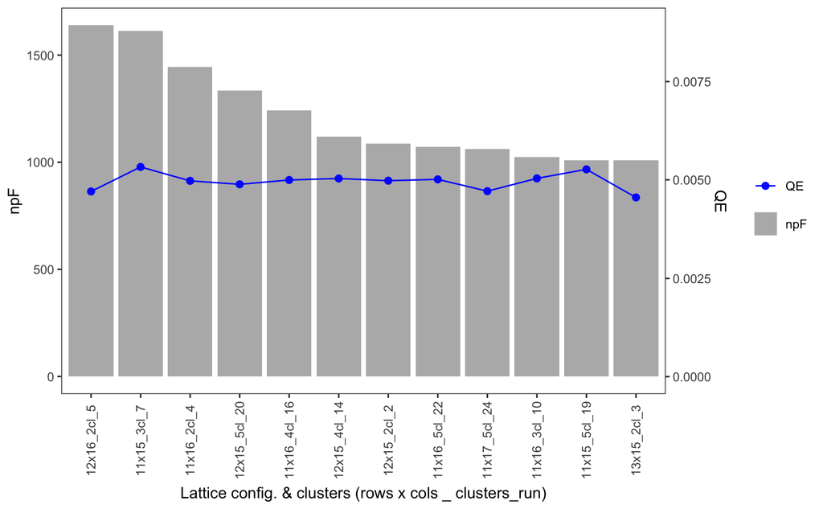

##### Choose the best run from each high performing (top 50%) cluster

```
## [1] These were the top runs for each high-performing cluster #:
```

| Run | rows | cols | Nodes | Clusters | npF | QE |
| --- | --- | --- | --- | --- | --- | --- |
| 7 | 11 | 15 | 165 | 3 | 1613.612 | 0.005 |
| 16 | 11 | 16 | 176 | 4 | 1242.923 | 0.005 |
| 20 | 12 | 15 | 180 | 5 | 1335.589 | 0.005 |

> To examine this run in greater detail (e.g., component planes), see the ‘X_SOMplots_site_ … .pdf’

##### 3 clusters - examine boxplots of independent variables by cluster

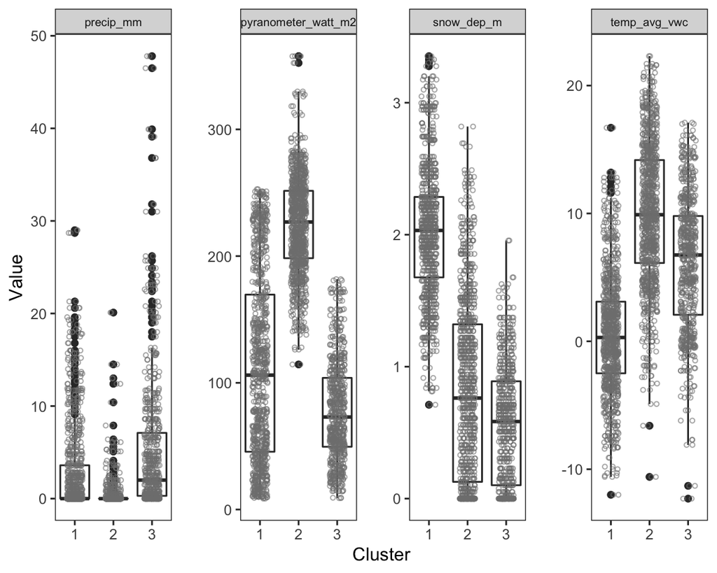

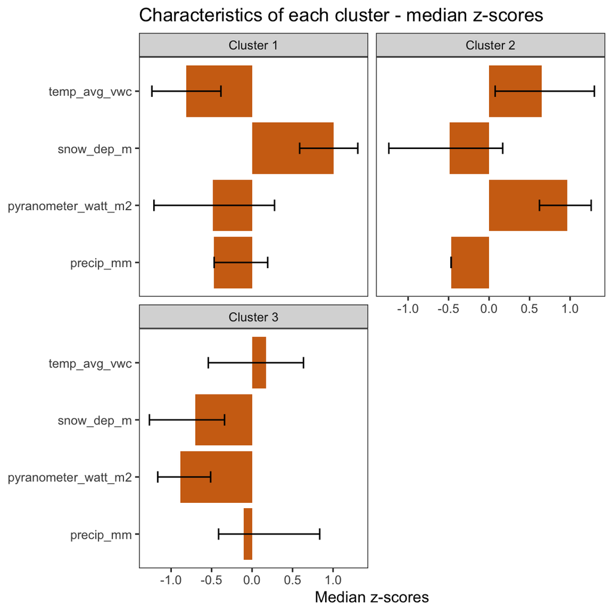

#### 3 clusters - examine how the clusters map on to the cumulative runoff curves

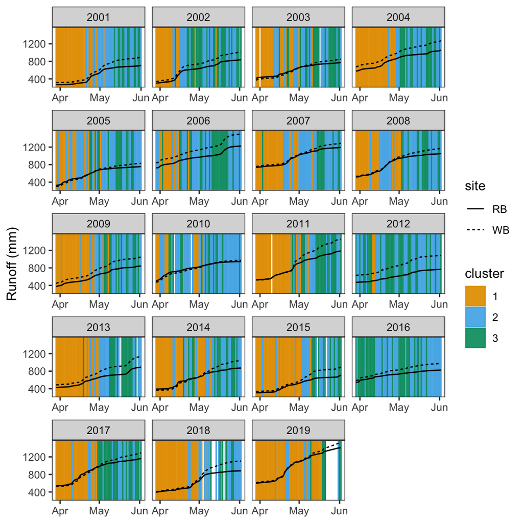

##### 4 clusters - examine boxplots of independent variables by cluster

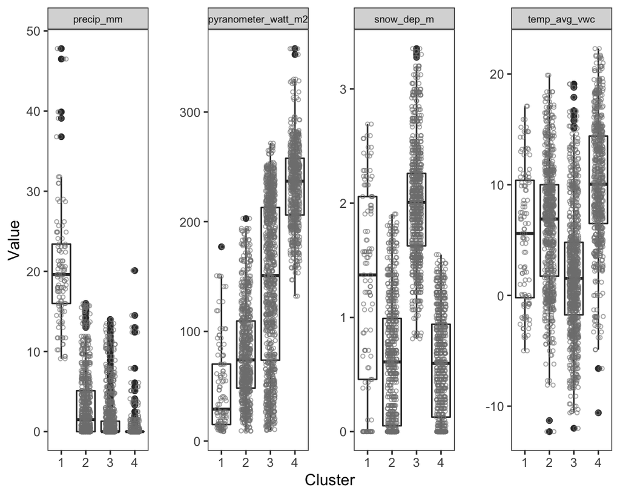

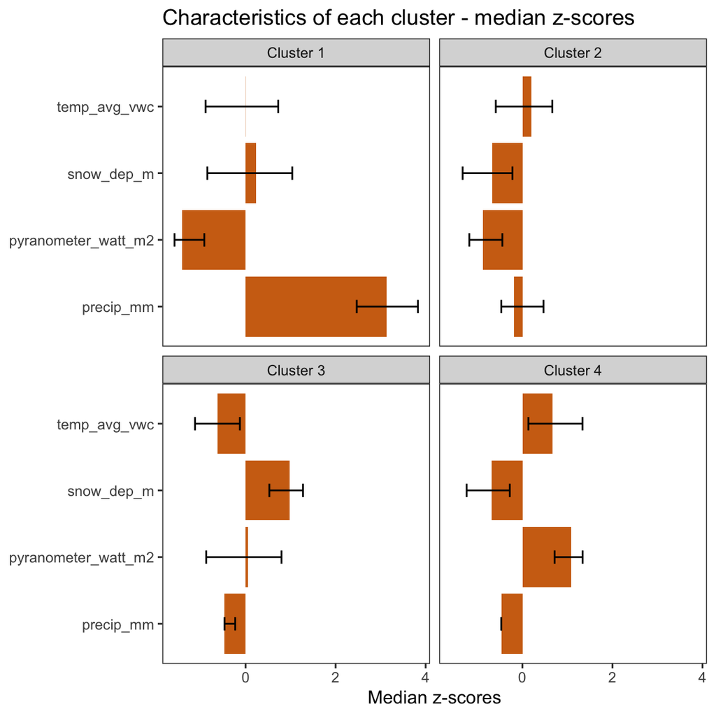

#### 4 clusters - examine how the clusters map on to the cumulative runoff curves

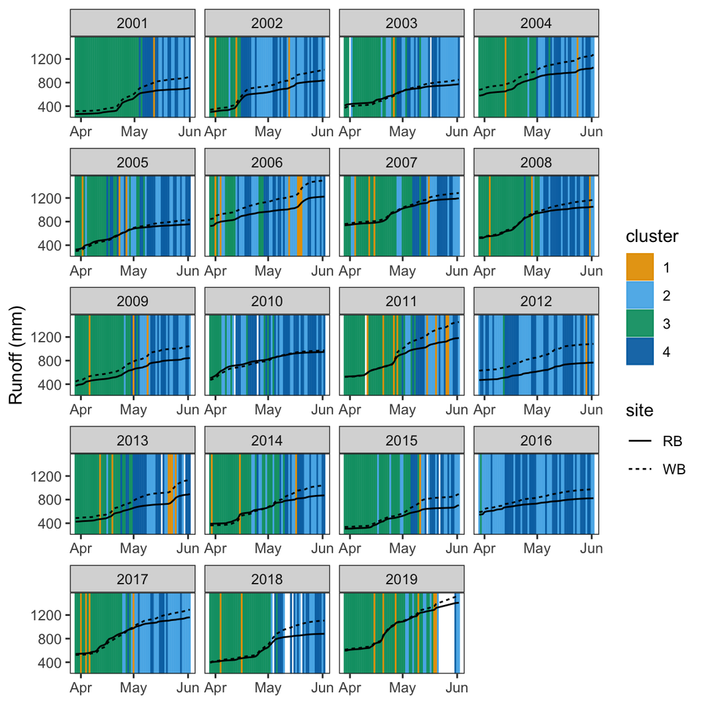

##### 5 clusters - examine boxplots of independent variables by cluster

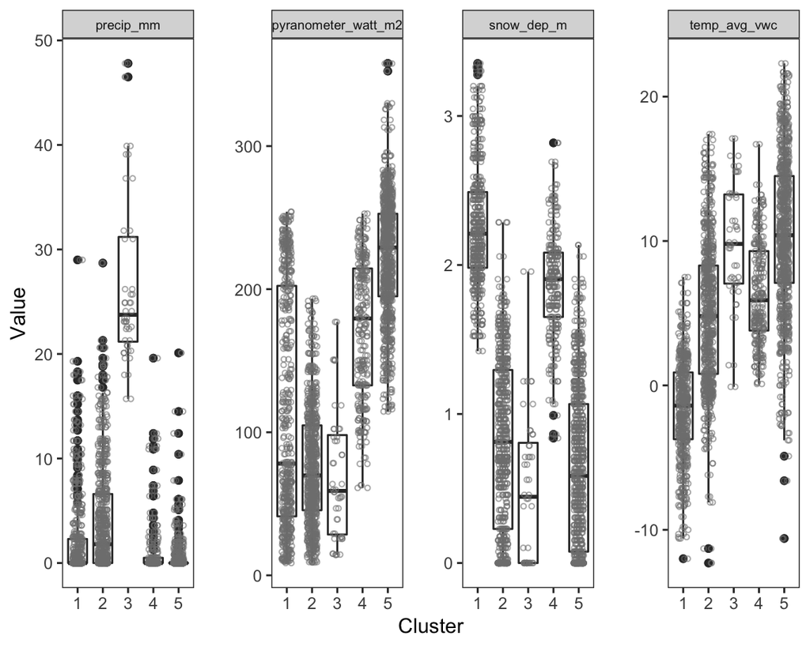

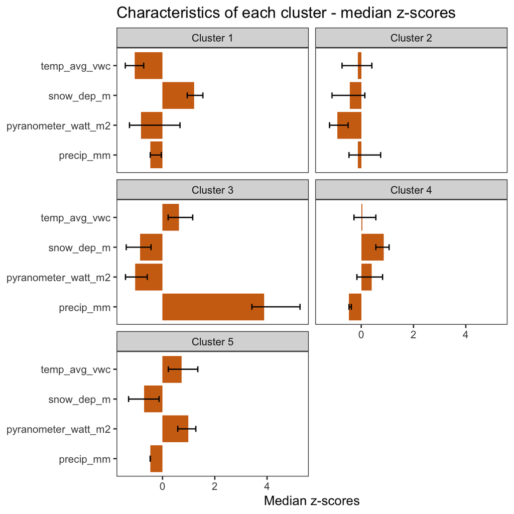

#### 5 clusters - examine how the clusters map on to the cumulative runoff curves

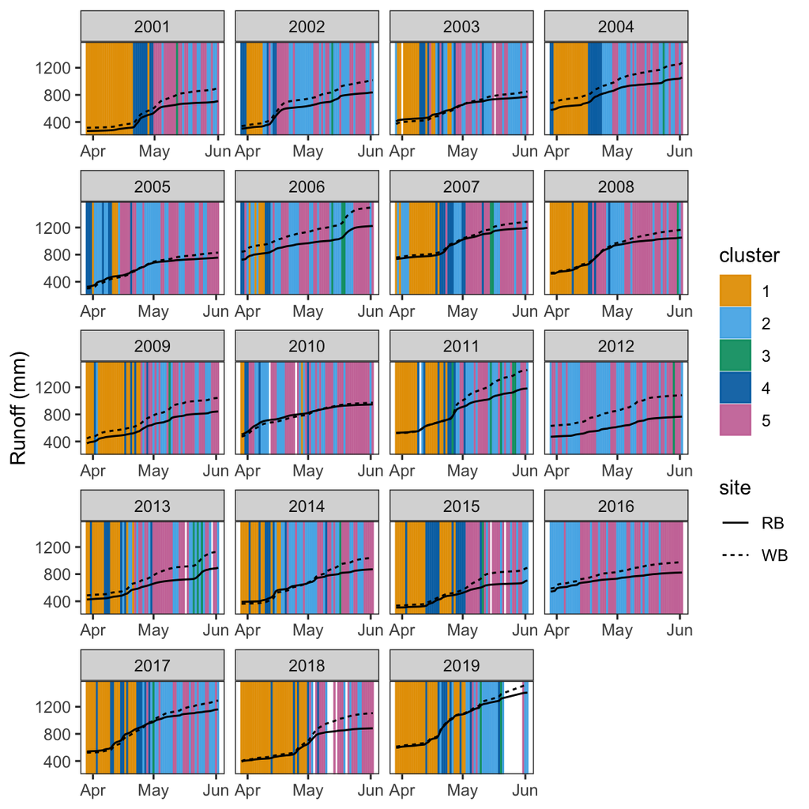